# PADD 3 Gasoline S/D Balance (Mid-Term)

## Complete Supply and Demand Balance

[interactive chart not shown]

PADD 3 Gasoline Material Balance

Supply and Disposition Components (2025-08 to 2026-07)

|  | 2025-08-31 | 2025-09-30 | 2025-10-31 | 2025-11-07 | 2025-11-14 | 2025-11-21 | 2025-11-28 | 2025-12-05 | 2025-12-12 | 2025-12-19 | 2025-12-26 | 2026-01-02 | 2026-01-09 | 2026-01-16 | 2026-01-23 | 2026-01-30 | 2026-02-06 | 2026-02-13 | 2026-02-20 | 2026-02-27 | 2026-03-06 | 2026-03-13 | 2026-03-20 | 2026-03-27 | 2026-04-03 | 2026-04-10 | 2026-04-17 | 2026-04-24 | 2026-05-01 | … |
| --- | --- | --- | --- | --- | --- | --- | --- | --- | --- | --- | --- | --- | --- | --- | --- | --- | --- | --- | --- | --- | --- | --- | --- | --- | --- | --- | --- | --- | --- | --- |
| **Supply, MBPD** |  |  |  |  |  |  |  |  |  |  |  |  |  |  |  |  |  |  |  |  |  |  |  |  |  |  |  |  |  | … |
| Receipts | 56 | 48 | 72 | 52 | 52 | 52 | 52 | 52 | 52 | 52 | 52 | 53 | 56 | 59 | 62 | 65 | 65 | 65 | 66 | 66 | 67 | 68 | 69 | 70 | 72 | 75 | 78 | 81 | 83 | … |
| Imports | 29 | 31 | 34 | 40 | 9 | 0 | 3 | 30 | 10 | 22 | 0 | 0 | 2 | 8 | 0 | 2 | 14 | 21 | 28 | 28 | 65 | 65 | 65 | 65 | 57 | 57 | 57 | 57 | 27 | … |
| Adjustments | 11 | −11 | 7 | 0 | 0 | 0 | 0 | 0 | 0 | 0 | 0 | 0 | 0 | 0 | 0 | 0 | 0 | 0 | 0 | 0 | 0 | 0 | 0 | 0 | 0 | 0 | 0 | 0 | 0 | … |
| E100 Input | 155 | 151 | 149 | 150 | 151 | 150 | 154 | 140 | 159 | 159 | 158 | 126 | 149 | 151 | 149 | 152 | 152 | 152 | 152 | 153 | 153 | 153 | 153 | 153 | 153 | 153 | 153 | 153 | 153 | … |
| Net E0 Production | 4,253 | 4,345 | 4,021 | 4,521 | 4,318 | 4,470 | 4,457 | 4,572 | 4,598 | 4,469 | 4,653 | 4,647 | 4,640 | 4,307 | 4,077 | 4,172 | 4,166 | 4,250 | 4,402 | 4,521 | 4,226 | 4,314 | 4,300 | 4,332 | 4,350 | 4,350 | 4,301 | 4,301 | 4,400 | … |
| Total Supply | 4,504 | 4,564 | 4,283 | 4,763 | 4,530 | 4,672 | 4,666 | 4,794 | 4,819 | 4,702 | 4,863 | 4,826 | 4,847 | 4,525 | 4,288 | 4,390 | 4,398 | 4,488 | 4,648 | 4,767 | 4,511 | 4,600 | 4,587 | 4,620 | 4,632 | 4,636 | 4,589 | 4,592 | 4,663 | … |
| **Dispositions, MBPD** |  |  |  |  |  |  |  |  |  |  |  |  |  |  |  |  |  |  |  |  |  |  |  |  |  |  |  |  |  | … |
| Gasoline Demand | 1,341 | 1,261 | 1,370 | 1,375 | 1,375 | 1,375 | 1,375 | 1,376 | 1,377 | 1,378 | 1,379 | 1,380 | 1,380 | 1,381 | 1,381 | 1,382 | 1,382 | 1,383 | 1,384 | 1,384 | 1,385 | 1,385 | 1,386 | 1,386 | 1,387 | 1,387 | 1,388 | 1,388 | 1,389 | … |
| Shipments | 2,505 | 2,496 | 2,305 | 2,318 | 2,318 | 2,318 | 2,318 | 2,320 | 2,323 | 2,326 | 2,329 | 2,331 | 2,331 | 2,331 | 2,331 | 2,331 | 2,331 | 2,331 | 2,331 | 2,331 | 2,331 | 2,331 | 2,331 | 2,331 | 2,331 | 2,331 | 2,331 | 2,331 | 2,331 | … |
| Exports | 787 | 829 | 802 | 1,005 | 1,120 | 1,358 | 1,184 | 930 | 985 | 1,185 | 677 | 1,089 | 866 | 973 | 708 | 677 | 684 | 774 | 933 | 1,052 | 795 | 884 | 870 | 903 | 915 | 917 | 870 | 873 | 943 | … |
| Stock change, MBPD | −129 | −24 | −257 | 140 | 213 | 320 | 606 | 160 | 49 | 152 | 423 | 328 | 212 | −26 | −182 | 0 | 0 | 0 | 0 | 0 | 0 | 0 | 0 | 0 | 0 | 0 | 0 | 0 | 0 | … |
| Stock change (MMBBL) | −4.0 | −0.7 | −1.8 | 1.0 | 1.5 | 2.2 | 4.2 | 1.1 | 0.3 | 1.1 | 3.0 | 2.3 | 1.5 | −0.2 | −1.3 | 0.0 | 0.0 | 0.0 | 0.0 | 0.0 | 0.0 | 0.0 | 0.0 | 0.0 | 0.0 | 0.0 | 0.0 | 0.0 | 0.0 | … |
| Total Dispositions | 4,504 | 4,562 | 4,219 | 4,838 | 5,026 | 5,371 | 5,483 | 4,786 | 4,734 | 5,041 | 4,808 | 5,128 | 4,789 | 4,659 | 4,238 | 4,390 | 4,398 | 4,488 | 4,648 | 4,767 | 4,511 | 4,600 | 4,587 | 4,620 | 4,632 | 4,636 | 4,589 | 4,592 | 4,663 | … |
| **Material Balance Error**<sup>1,2,3</sup> |  |  |  |  |  |  |  |  |  |  |  |  |  |  |  |  |  |  |  |  |  |  |  |  |  |  |  |  |  | … |
| MBPD | 0 | 0 | 65 | −75 | −495 | −700 | −815 | 10 | 85 | −340 | 55 | −300 | 60 | −135 | 50 | 0 | 0 | 0 | 0 | 0 | 0 | 0 | 0 | 0 | 0 | 0 | 0 | 0 | 0 | … |
| Cumulative (MMBBL) | 0 | 0 | 0 | −1 | −4 | −9 | −15 | −15 | −14 | −16 | −16 | −18 | −18 | −19 | −19 | 0 | 0 | 0 | 0 | 0 | 0 | 0 | 0 | 0 | 0 | 0 | 0 | 0 | 0 | … |

<sup>1</sup> Note 1: Mat. balance error is calculated for the period between last EIA monthly date and last EIA weekly date. Before last EIA monthly date, material balance is closed perfectly by EIA. After last EIA weekyl date, material balance is closed perfectly by our internal calculations (with exports being the calculated component)  
<sup>2</sup> Note 2: Three most uncertain components of material balance are 1. Demand, 2. Shipments/Receipts and 3. Production  
<sup>3</sup> Note 3: Negative error implies actual demand or shipments should be lower than forecasted. Production or receipts could also be higher than forecasted

[interactive chart not shown]

## Kpler Export Trade Flows

PADD 3 Gasoline Exports/Shipments, MBPD (2025-01-28 - 2026-01-28)

Note: Net flows (including intra-PADD). Does not include barge movements

[interactive chart not shown]

PADD 3 Gasoline Exports

Annual Average Exports (kbpd) by Destination Country

|  | 2019 | 2020 | 2021 | 2022 | 2023 | 2024 | 2025 | 2026 |
| --- | --- | --- | --- | --- | --- | --- | --- | --- |
| Mexico | 375 | 286 | 316 | 365 | 363 | 348 | 327 | 153 |
| Brazil | 106 | 111 | 128 | 90 | 51 | 56 | 79 | 84 |
| Colombia | 66 | 61 | 74 | 78 | 64 | 74 | 71 | 62 |
| Bahamas | 3 | 8 | 13 | 36 | 43 | 44 | 74 | 138 |
| Guatemala | 23 | 20 | 31 | 35 | 36 | 38 | 42 | 38 |
| Ecuador | 28 | 17 | 19 | 26 | 29 | 29 | 50 | 39 |
| Others | 292 | 300 | 390 | 321 | 318 | 383 | 355 | 239 |
| Total by Kpler | 893 | 803 | 970 | 951 | 903 | 973 | 998 | 752 |
| Total by EIA<sup>1</sup> | 831 | 709 | 835 | 889 | 848 | 820 | 802 | NA |

<sup>1</sup> Kpler->EIA correction coefficient = 0.8561

**PADD 3 Export Data Calibration vs US Export Data**

[interactive chart not shown]

**PADD 3 Import Data**

### EIA Imports by State and Origin Countries/Continents

[interactive chart not shown]

## Kpler Import Trade Flows

PADD 3 Gasoline Imports/Receipts, MBPD (2025-01-28 - 2026-01-28)

Note: Net flows (including intra-PADD). Does not include barge movements

[interactive chart not shown]

## Price Data

**Note**

[interactive chart not shown]

[output not shown]

[interactive chart not shown]

### USGC CBOB Basis (RVP-adjusted) vs RBOB Crack Correlation

**Click to expand**

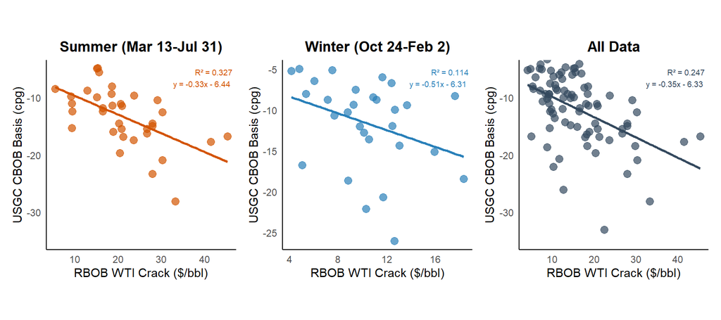

### Rolling Correlation (12-Month Window)

**Click to expand**

[interactive chart not shown]

## Data Status

**Click to expand**

| Data Source | Last Update | Status (24h) |
| --- | --- | --- |
| MarketView Curves | 2026-01-28 09:16 | ✅ |
| MarketView Prices | 2026-01-28 09:02 | ✅ |
| Kpler CPP | 2026-01-28 09:19 | ✅ |
| IIR | 2026-01-28 08:50 | ✅ |
| EIA ETL | 2026-01-28 10:42 | ✅ |
| CEC WFW | 2026-01-28 08:45 | ✅ |
| EIA Company | 2026-01-28 08:55 | ✅ |

## To-do

- Provide outlook on USGC stocks up to 6 months out (build vs draw)
- Incorporate impact of secondary units (FCC, Reformer) on gasoline production
- Add C5 vs RBOB price comparison
- Track August CRB + Sept/Oct RBOB spread. Check additional correlations
- Incorporate Sunoco’s POS data to better forecast demand
- Incorporate Sunoco’s CPL data to better forecast pipeline Shipments - not available
- Incorporate Sunoco’s and Kpler’s data to better forecast marine shipments to PADD 1 (barges may not be GPS-tracked)
- Data to-do’s
  - Need to confirm if USGC blendstock asessements includes RVO
  - The script lacks comprehensive error handling for data quality issues that could cause silent failures or incorrect forecasts. Add data validation functions

## Notes

- See file “PADD 3 Gasoline SnD Forecasting Methodology.md” for additional details